# 05. 랜덤화블록계획과 라틴정방계획

## 05.01. 랜덤화블록계획

### 랜덤화블록계획 (randomized block design)

- **실험전체가 동질적이 아닌경우, 실험 전체를 될 수 있는 한 동질적인 블록으로 나눈 후**

  **각 블록 내에서 랜덤화를 적용하여 요인의 효과를 파악하는 것**

  **(블록 내 동질적, 블록 간 이질적)**
- 블록화를 통하여 관심 있는 요인의 수준 간 효과의 차이를 더욱 확실히 파악

### 완전랜덤화계획 (completely randomized design)

- 실험단위가 모두 비슷해야하는 조건 존재

  $\rightarrow$ 조건 만족 못할 시, 동질적인 실험단위로 블록화

### 비료와 농지에 대한 예시 (완전랜덤화계획 $\rightarrow$ 랜덤화블록계획)

- 비료의 3가지의 효능 비교 $\rightarrow$ 9개의 농지를 확보하여, 각 농지마다 랜덤하게 비료를 배정 $\rightarrow$ 완전랜덤화게획
  - **농지마다 토질이 다르다면, 완전랜덤화계획으로 인하여 실험 계획이 문제**

    분산분석결과가 나오더라도, 그 것이 비료의 차이때문인지, 토질의 차이인지 알 수 없음

| 비료1 | 비료2 | 비료3 |
| --- | --- | --- |
| 농지8 (모래) | 농지9 (모래) | 농지5 (진흙) |
| 농지2 (흙) | 농지1 (진흙) | 농지7 (모래) |
| 농지3 (흙) | 농지4 (진흙) | 농지6 (진흙) |

- 각 토질마다 세 가지 비료가 모두 나타나게끔 농지를 배정

  **$\rightarrow$ 각 토질마다 세 가지 비료가 모두 나타나게 실험을 계획하는 것은 $\rightarrow$ 완전랜덤화를 포기**

  **이러한 제한을 통해서 토질이 수확량에 미치는 영향은 상쇄, 순수한 비료효과만 계산할 수 있음**

#### 이 경우 토질은 블록

| 토질 | 비료1 | 비료2 | 비료3 |
| --- | --- | --- | --- |
| 흙 | 농지2 | 농지3 | 농지1 |
| 진흙 | 농지4 | 농지6 | 농지5 |
| 모래 | 농지9 | 농지8 | 농지7 |

### 랜덤화블록계획의 설계방식

($a$ = 반복횟수)

$$블록 1 : x_{11} \dots x_{a1}$$$$블록 2 : x_{11} \dots x_{a1}$$$$\vdots$$$$블록 b : x_{1b} \dots x_{ab}$$

- **랜덤화블록계획의 본질은 블록의 차이에 따른 효과를 보는 것이 아닌**

  **블록의 효과를 억제해주기 위함**
  - **$\mu$ : 전체평균**
  - **$\gamma_i$ : 고정요인의 관심요인의 $i$번째 수준의 효과**
  - **$\beta_j$ : 블록요인의 $j$번째 수준의 효과**
  - **$\epsilon_{ij}$ : 오차항으로 서로 독립인 $N(0, \sigma^2_E)$를 따름**

  $$x_{ij} =\mu + \gamma_i + \beta_j + \epsilon_{ij},\;\;\;i=1, 2, \dots , a;\;\;\;j=1,2, \dots, b$$

#### 가설설정

- $H_0 : \gamma_1 = \gamma_a = 0$ vs $H_1 :\;not\;H_0$

#### 변동의 계산

- $CT(=수정항) = {{T^2}\over{ab}}$일 떄,

  $$SS_T = \sum_i \sum_j x^2_{ij} - CT$$

  $$SS_A = \sum_i {{T^2_{i.}}\over{b}} - CT$$

  $$SS_B = \sum_j {{T^2_{.j}}\over{a}} - CT$$

#### 자유도 계산

$$\phi_T = ab-1$$$$\phi_A = a-1$$$$\phi_B = b-1$$$$\phi_E = (a-1)(b-1)$$

#### 평균제곱의 기댓값과 F검정

- **평균제곱 $MS_A, MS_B, MS_E$는 각각의 변동을 자유도로 나눠 준 값**
- A에 대한 귀무가설 $H_0:\gamma_1 = \dots = \gamma_a = 0$하에서는 $F_0 =MS_A / MS_E$가 자유도 ($\phi_A, \phi_E$)인 F분포를 따름

  요인 A에 대한 귀무가설의 기각역은

  $$F_0 > F(\phi_A, \phi_E;\;\;\alpha)$$

#### 귀무가설이 기각되면 A가 특성값에 유의한 영향을 줌

#### 분산분석표

| 요인 | 제곱합 | 자유도 | 평균제곱 | $F_0$ |
| --- | --- | --- | --- | --- |
| $A$ | $SS_A$ | $a$-$1$ | $MS_A$ | $MS_A$/$MS_E$ |
| 블록요인$B$ | $SS_B$ | $b$-$1$ | $MS_B$ |  |
| $E$ | $SS_E$ | $(a$-$1)b$-1$)$ | $MS_E$ |  |
| $T$ | $SS_T$ | $ab$-$1$ |  |  |

#### 랜덤화블록계획은 블록 간에 서로 이질적일수록, 완전랜덤화법에 비하여 잔차변동을 줄일 수 있음

**하지만, 블록 간에 별 차이가 없다면, 랜덤화블록계획은 완전랜덤화법에 비하여 자유도가 $a(b-1)-(a-1)(b-1) = b-1$만큼 줄어들어**

**검출력이 나빠질 수 있음**

- 이 경우, 블록요인에 대한 유의확률을 구하여, 유의확률이 0.25이상이면 오차항에 풀링 (변수 제거) $\rightarrow$ 블록효과가 존재하지 않는다고 판단

#### 플라스팀 제품예시

- 랜덤하게 4일 ($B_1, B_2, B_3, B_4$)
- 실험일마다 공장의 가열온도를 3수준 ($A_1, A_2, A_3$)으로 랜덤하게 변화 (블록요인)

```r
library(tidymodels)
library(tidyverse)
```

```r
y <- c(98, 99, 98.6, 97.6, 97.7, 98, 98.2, 97.3, 96.5, 97.9, 96.9, 96.7)
a <- c(rep(1, 4), c(rep(2, 4), rep(3, 4))); b <- c(rep(c(1:4), 3))

strength = tibble(y, a, b) %>%
    mutate(a = factor(a), b = factor(b))
```

```r
strength %>% pivot_wider(id_cols = a, values_from = y, names_from = b)
```

A tibble: 3 × 5

| a <fct> | 1 <dbl> | 2 <dbl> | 3 <dbl> | 4 <dbl> |
| --- | --- | --- | --- | --- |
| 1 | 98.0 | 99.0 | 98.6 | 97.6 |
| 2 | 97.7 | 98.0 | 98.2 | 97.3 |
| 3 | 96.5 | 97.9 | 96.9 | 96.7 |

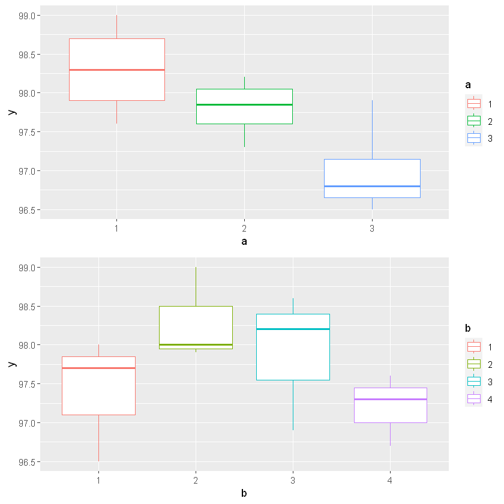

```r
p1 <- strength %>% ggplot() + geom_boxplot(aes(a, y, color = a))
p2 <- strength %>% ggplot() + geom_boxplot(aes(b, y, color = b))
gridExtra::grid.arrange(p1, p2)
```

- 분산분석표

```r
anova <- aov(y ~ a + b, strength)
```

```r
tidy(anova)
```

A tibble: 3 × 6

| term <chr> | df <dbl> | sumsq <dbl> | meansq <dbl> | statistic <dbl> | p.value <dbl> |
| --- | --- | --- | --- | --- | --- |
| a | 2 | 3.44 | 1.72000000 | 18.428571 | 0.0027440 |
| b | 3 | 2.22 | 0.74000000 | 7.928571 | 0.0164702 |
| Residuals | 6 | 0.56 | 0.09333333 | NA | NA |

- F검정 $\rightarrow$ : $F_0 = 1.72/0.093 = 18.4286$ > $F_{2, 6, 0.01}$
  - 온도A는 유의수준 $\alpha = 0.01$에서 유의 $\rightarrow$ 가열온도에 따라 제품의 강도가 모두 같지는 않음

```r
1.72000000 / 0.09333333
```

18.4285720867347

```r
qf(p = 0.01, df1 = 2, df2 = 6, lower.tail = F)
```

10.9247665008383

```r
pairwise.t.test(y, a, p.adf = "none")
```

```
	Pairwise comparisons using t tests with pooled SD

data:  y and a

  1     2
2 0.235 -
3 0.027 0.145

P value adjustment method: holm
```

- 온도의 3수준 중 $A_1$수준이 제품강도를 높이는데에는 최적

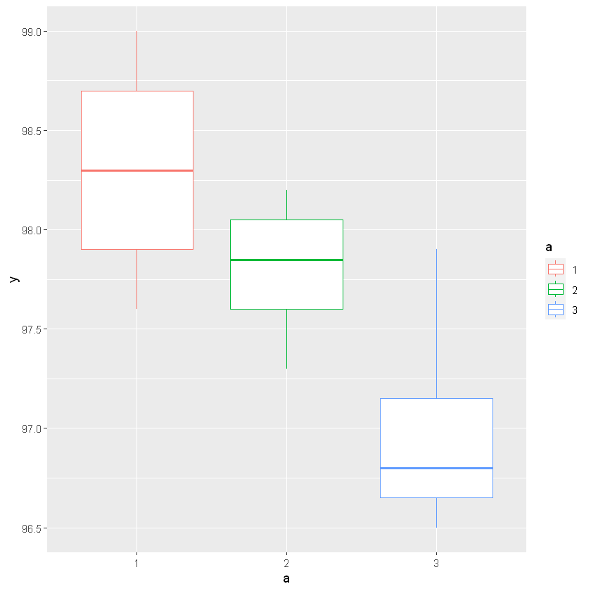

```r
strength %>% ggplot() + geom_boxplot(aes(a, y, color = a))
```

- 온도 이외에 실험일의 효과도 유의함
  - 따라서, $\hat{\sigma^2_B} = {{MS_B - MS_E}\over{a}} = {{0.74-0.093}\over{3}}=0.216$

## 05.02. 라틴정방계획

- **실험단위의 동질성을 분류할 수 있는 블록요인이 2개 있는 경우, 랜덤화블록계획의 개념을 확장시킨 실험계획**

  규칙적인 두 방향의 블록화를 용인하여 처리효과의 유의성을 탐지하는데 장애가 되는 두 가지 변동의 근원을 제거

  (본래 농업실험에서, 변동의 원인인 2가지를 근원적으로 제거하는데 사용)

### 비료실험 예시

- 5가지 비료가 생산에 미치는 효과를 판정할 때, 농지에 5X5 격자선을 그어 모두 25개의 시험구를 생성

|  | 1 | 2 | 3 | 4 | 5 |
| --- | --- | --- | --- | --- | --- |
| $I$ | A | B | C | D | E |
| $II$ | C | D | E | A | B |
| $III$ | E | A | B | C | D |
| $IV$ | B | C | D | E | A |
| $V$ | D | E | A | B | C |

- 라틴정방계획의 배열에서는 각 행과 열마다 처리들이 정확히 한 번씩 등장
- **만약, 토양의 습윤도가 행을 따라 변화하며, 토지의 비옥도가 열을 따라 일정하지 않을 때**

  **시험구 내 두방향의 토지 비옥도 차이로 인한 감자 생산의 변동은 라틴정방계획으로 제거**

  **$\rightarrow$ 두 방향의 비옥도 차이를 행블록과 열블록으로 잡아, 토지비옥도가 생산에 미치는 영향을 제거한 다음 비료의 효과만 분석**

### $p\times p$ 라틴정방

- $p$개의 행과, $p$개의 열을 갖는 정사각형

  행과 열이 교차하여 이루는 $p^2$개의 위치에는 각 위치마다 처리에 대응되는 $p$개의 라틴글자 중 하나를 늘 포함하며

  각 글자는 각 행과 열에서 단 한번만 나타남
- 행블록 요인 $R$, 열블록 요인 $C$, 관심요인 $Trt$일 때, $p\times p$라틴 정방계획의 통계모형은
  - **$\rho_i$ : $i$번째 행의 효과**
  - **$\gamma_j$ : $j$번째 열의 효과**
  - **$\tau_k$ : $k$번째 처리의 효과**
  - **관심요인과 행블록, 열블록의 수준수가 반드시 모두 같아야 하며, 데이터의 수는 $p^2$개**

$$x_{ijk} = \mu + \rho_i + \gamma_j+ \tau_k + \epsilon_{ijk}\;\;\;(i, j, k=1, \dots, p)$$

**라틴정방계획에서 상호작용효과는 검증불가**

- 오로지 주효과의 통계적 유의성을 검증할 수 있으며, 실험이 간단

### 제곱합 및 자유도 분할

$$SS_T = SS_R + SS_C + SS_{Trt} + SS_E$$$$p^2 -1 = (p-1) + (p-1) + (p-1) + (p-1)(p-2)$$
$$SS_T = \sum^p_i\sum^p_j \sum^p_k (x_{ijk} - \bar{\bar{x}})^2 = \sum^p_i\sum^p_j \sum^p_k (x_{ijk})^2-{{T^2}\over{p^2}}$$$$SS_R = \sum^p_i\sum^p_j \sum^p_k (\bar{x_{i..}}-\bar{\bar{x}})^2 = {1\over p}\sum^p_i T^2_{i..}-{{T^2}\over{p^2}}$$$$SS_R = \sum^p_i\sum^p_j \sum^p_k (\bar{x_{.j.}}-\bar{\bar{x}})^2 = {1\over p}\sum^p_j T^2_{.j.}-{{T^2}\over{p^2}}$$$$SS_{Trt} = \sum^p_i\sum^p_j \sum^p_k (x_{..k} - \bar{\bar{x}})^2 = {1\over p}\sum^p_k T^2_{..k}-{{T^2}\over{p^2}}$$$$SS_E = SS_T - SS_R - SS_C - SS_{Trt}$$

### 가설설정 및 검정통계량

$$H_0 : \tau_k = 0\;\;\;(k=1. \dots, p)$$

- 검정통계량

$$F_0 = {{MS_{Trt}}\over{MS_E}}$$

이며, 만일 $F_0 > F(p-1, (p-2)(p-1);\;\;\alpha)$면 귀무가설을 기각

$\rightarrow$ 어느수준 간에는 효과의 차이가 존재한다고 결론

### 분산분석표

[output not shown]

### 로켓성능 예시

- 5가지 로켓 추진제 ($Trt$)
- 원료 $R$와 기사 숙련도 $C$마다 추진제의 성능에 영향
- 추진제의 성능평가를 위해, 원료 간의 변동과 기사 간 변동을 제거

```r
y <- c(-1, -5, -6, -1, -1, -8, -1, 5, 2, 11, -7, 13, 1, 2, -4, 1, 6, 1, -2, -3, -3, 5, -5, 4, 6)
row <- factor(c(rep(1, 5), rep(2, 5), rep(3, 5), rep(4, 5), rep(5, 5)))
col <- factor(c(rep(c(1, 2, 3, 4, 5), 5)))
trt <- c(c("a", "b", "c", "d", "e",
           "b", "c", "d", "e", "a",
           "c", "d", "e", "a", "b",
           "d", "e", "a", "b", "c",
           "e", "a", "b", "c", "d"))
rocket.data = tibble(y, row, col, trt)
```

```r
rocket.data %>% mutate(val = paste0(col, " (", trt, ")")) %>%
    pivot_wider(id_cols = col, values_from = val, names_from = row)
```

A tibble: 5 × 6

| col <fct> | 1 <chr> | 2 <chr> | 3 <chr> | 4 <chr> | 5 <chr> |
| --- | --- | --- | --- | --- | --- |
| 1 | 1 (a) | 1 (b) | 1 (c) | 1 (d) | 1 (e) |
| 2 | 2 (b) | 2 (c) | 2 (d) | 2 (e) | 2 (a) |
| 3 | 3 (c) | 3 (d) | 3 (e) | 3 (a) | 3 (b) |
| 4 | 4 (d) | 4 (e) | 4 (a) | 4 (b) | 4 (c) |
| 5 | 5 (e) | 5 (a) | 5 (b) | 5 (c) | 5 (d) |

- 추진제($Trt$) 간 차이가 통계적으로 유의 $\rightarrow$ 추진제에 따라 성능이 모두 같지 않음 $\rightarrow$ 추후분석이 필요

```r
anova <- aov(y ~ row + col + trt, rocket.data)
tidy(anova)
```

A tibble: 4 × 6

| term <chr> | df <dbl> | sumsq <dbl> | meansq <dbl> | statistic <dbl> | p.value <dbl> |
| --- | --- | --- | --- | --- | --- |
| row | 4 | 68 | 17.00000 | 1.593750 | 0.239058537 |
| col | 4 | 150 | 37.50000 | 3.515625 | 0.040373048 |
| trt | 4 | 330 | 82.50000 | 7.734375 | 0.002536502 |
| Residuals | 12 | 128 | 10.66667 | NA | NA |

- $Trt_a$와 $Trt_b$, $Trt_b$와 $Trt_d$의 차이가 유의

```r
pairwise.t.test(y, trt, p.adf = "none")
```

```
	Pairwise comparisons using t tests with pooled SD

data:  y and trt

  a     b     c     d
b 0.041 -     -     -
c 0.201 1.000 -     -
d 1.000 0.016 0.086 -
e 1.000 0.236 0.820 0.820

P value adjustment method: holm
```

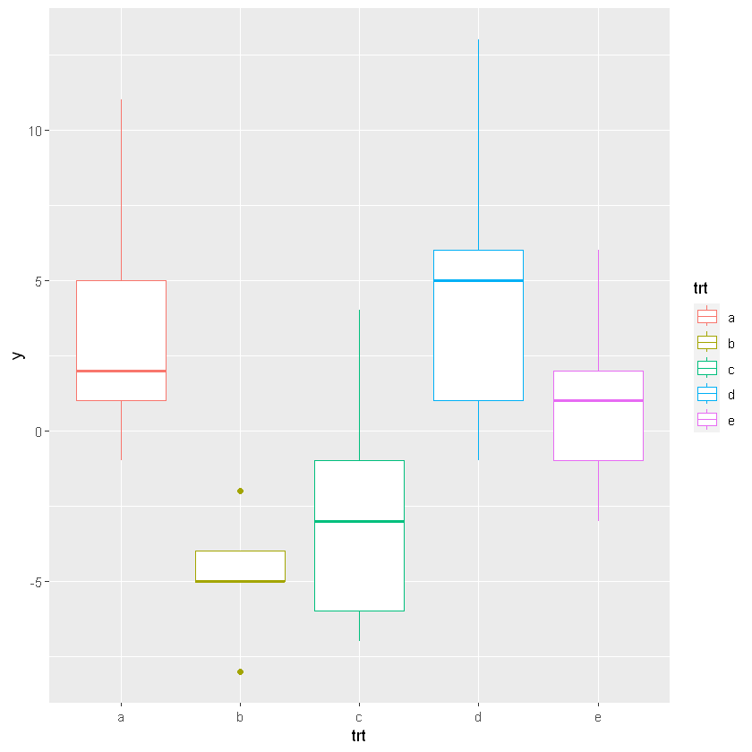

```r
ggplot(rocket.data) + geom_boxplot(aes(trt, y, color = trt))
```

## 05.03. 라틴정방의 구축

### 1단계

- 2개의 블록요인을 행과 열에 랜덤하게 배치

### 2단계

- 표준형계획에서 행의 순서를 랜덤하게 배열, 열의 순서를 랜덤하게 배열

$$\begin{bmatrix}A&B&C\\B&C&A\\C&A&B \end{bmatrix} \rightarrow \begin{bmatrix}B&C&A\\A&B&C\\C&A&B \end{bmatrix} \rightarrow \begin{bmatrix}A&B&C\\C&A&B\\B&C&A \end{bmatrix}$$$$표준형 \rightarrow 행의\;랜덤화 \rightarrow 열의\;랜덤화$$

#### 라틴정방계획은 일부실시법에 해당

- 예
  - 수준이 3개인 블록요인이 2개 있고, 관심요한 또한 수준이 3개인 경우

    표준형은 전체$3^3$ 실험 중 일부인 $3^{3-1}$개의 조건에 실험이 이루어짐
  - 3원배치법인 $3^3$실험에서와 같이 모든 조건에서 실험이 이루어지지는 않았지만, 각 행과 열과 각 문자에서 3번씩 실험이 진행

$$\begin{bmatrix}A&B&C\\B&C&A\\C&A&B \end{bmatrix}$$

$$\downarrow$$

|  |  | 열1 | 열2 | 열3 |
| --- | --- | --- | --- | --- |
| 행1 | A B C | O $\;$ $\;$ | $\;$ O $\;$ | $\;$ $\;$ O |
| 행2 | A B C | $\;$ O $\;$ | $\;$ $\;$ O | O $\;$ $\;$ |
| 행3 | A B C | $\;$ $\;$ O | O $\;$ $\;$ | $\;$ O $\;$ |